# Delta_Hedging_Final

##### Professor: Jose Mario Zárate Carbajal

[figure not shown]

### By: Esteban Márquez Delgado

#### Introduction:

Merton and Scholes received the 1997 Nobel Prize in Economic Sciences for their work with the Black-Sholes model. Its formula provides a great way to hedge options by buying or selling the underlying asset in order to mitigate risks for investments. "The Greeks" measure the sensitivity of the value of a derivative or a portfolio to changes in parameter value(s) while holding the other parameters fixed. They are partial derivatives of the price with respect to the parameter values, they will be modelled in this paper in order to hedge with $\Delta$ and $\Delta \Gamma$.

**Libraries:**

```python
import warnings
warnings.filterwarnings("ignore", category=UserWarning)
import numpy as np
from yahoofinancials import YahooFinancials #Financial data download solution 1
import yfinance as yf #Financial data download solution 2
import pandas_datareader as pdr
import pandas_datareader.data as web #Data extraction from the web.
import datetime #Modules to work with date and time
from datetime import datetime, timedelta, date
from re import I
import scipy.stats as st #Statistics lib
import statsmodels.api as sm
import scipy as sp
import scipy.optimize as optimize
import scipy.cluster.hierarchy as hac
import seaborn as sns #Seaborn visualization lib
import matplotlib.pyplot as plt
import scipy.stats as st
from IPython.core.debugger import Pdb
from IPython.display import HTML
import IPython.core.display as di # Example: di.display_html('<h3>%s:</h3>' % str, raw=True)
import matplotlib.animation as animation
from matplotlib.pyplot import figure #Visualization presentation lib in matplot.
from matplotlib import cm
import kaleido
from mpl_toolkits.mplot3d import axes3d
import scipy.stats as st
from scipy.stats import norm
import mibian
import math
import yfinance as yf
from __future__ import print_function
import write
from tqdm import tqdm
import plotly.graph_objects as go
import io
from plotly.subplots import make_subplots
import dash
from dash import dcc
from dash import html
import plotly.express as px
from jupyter_dash import JupyterDash
import io
import pandas as pd

plt.style.use('fivethirtyeight')
colorscale = 'rdbu'

%matplotlib notebook
%matplotlib inline
```

**Functions:**

```python
def plot(closes, titulo):
    """
    Plot historical prices of asset(s) or time series.
    *closes : Historical prices.
    *title: Title of the df
    """
    #Styles
    plt.style.use('dark_background')
    plt.rc('grid', linestyle="--", color='gray')
    plt.rc('ytick', labelsize=13, color='gray')
    plt.rc('xtick', labelsize=13, color='gray')

    #Plot
    closes.plot(figsize = (16, 8), linewidth=.9)
    plt.title(titulo)
    plt.grid(True)
    plt.legend(loc = "best")

def gbm(S0: float, r: float, sigma: float, T: float, time_steps: int, n_paths: int,
        random_generator = st.norm(0, 1)):

    dt = float(T) / time_steps
    paths = np.zeros((time_steps + 1, n_paths), np.float64)
    paths[0] = S0
    for t in range(1, time_steps + 1):
        rand = random_generator.rvs(size = n_paths)
        paths[t] = paths[t - 1] * np.exp((r - 0.5 * sigma ** 2) * dt +
                                         sigma * np.sqrt(dt) * rand)
    return paths

    #%% Quick Report
def dqr(data):

    cols = pd.DataFrame(list(data.columns.values),
                           columns=['Name'],
                           index=list(data.columns.values))
    dtyp = pd.DataFrame(data.dtypes,columns=['Type'])
    misval = pd.DataFrame(data.isnull().sum(),
                                  columns=['N/A value'])
    presval = pd.DataFrame(data.count(),
                                  columns=['Count values'])
    unival = pd.DataFrame(columns=['Unique values'])
    minval = pd.DataFrame(columns=['Min'])
    maxval = pd.DataFrame(columns=['Max'])
    mean =pd.DataFrame(data.mean(), columns=['Mean'])
    Std =pd.DataFrame(data.std(), columns=['Std'])
    Var =pd.DataFrame(data.var(), columns=['Var'])
    median =pd.DataFrame(data.median(), columns=['Median'])

    skewness = pd.DataFrame(data.skew(), columns=['Skewness'])
    kurtosis = pd.DataFrame(data.kurtosis(), columns=['Kurtosis'])

    for col in list(data.columns.values):
        unival.loc[col] = [data[col].nunique()]
        try:
            minval.loc[col] = [data[col].min()]
            maxval.loc[col] = [data[col].max()]
        except:
            pass

    # Join table
    return cols.join(dtyp).join(misval).join(presval).join(unival).join(minval).join(maxval).join(mean).join(Std).join(Var).join(median).join(skewness).join(kurtosis)


def GBM_sim(S, mu, T, sigma, N):

    dt = T/N
    W = np.random.standard_normal(size=N-1)
    W = np.array([0] + list(np.cumsum(W)*np.sqrt(dt)))
    t = np.linspace(0, T, N)
    S = S*np.exp((mu - 0.5*sigma**2)*t + sigma*W)
    return S,t

def delta(S,K,T,r,q,sigma,CallPut):

    d1 = (np.log(S/K) + (r - q + 0.5*sigma**2)*T)/(sigma*np.sqrt(T))
    if CallPut == 'Call':
        return st.norm.cdf(d1)*np.exp(-q*T)

    elif CallPut == 'Put':
        return st.norm.cdf(d1)*np.exp(-q*T) - 1.0


def hedge(stock_trajectory, option_to_hedge):

    gbm_traj = stock_trajectory
    K = option_to_hedge.strikePrice
    r = option_to_hedge.interestRate
    T1 = option_to_hedge.daysToExpiration
    sig = option_to_hedge.volatility

    t_axis = np.linspace(0, T1, len(gbm_traj))
    dt = t_axis[1] - t_axis[0]


    Vt = []
    St = []
    t=[]

    Strategies = {'DeltaHedge': {"t": [],
                                 "Value": [],
                                 "Stock": [],
                                 "MM": []}
                 }
    for S, t_ in zip(gbm_traj[:-1], t_axis[:-1]):

        option_V = mibian.BS([S, K, r*100, (T1-t_)*365], volatility = sig*100)

        V = option_V.callPrice
        S = S

        if t_ == 0:
            DH = 0.0 # current value of delta hedged portfolio "hedge" part
        else:
            DH = Strategies['DeltaHedge']['Stock'][-1]*S + Strategies['DeltaHedge']['MM'][-1]*np.exp(r*dt)

        Strategies['DeltaHedge']['Value'].append(DH)

        Vt.append(V)
        St.append(S)
        t.append(t_)

        # Greeks
        delta_V = option_V.callDelta
        delta_S = 1.0

        gamma_V = option_V.gamma
        gamma_S = 0.0

        # Delta hedging
        A = np.array([[delta_S, 0], [S, 1]])
        B = np.array([[delta_V], [DH]])
        X = np.linalg.solve(A, B)

        Strategies['DeltaHedge']['Stock'].append(X[0][0])
        Strategies['DeltaHedge']['MM'].append(X[1][0])


    t = np.array(t).reshape(-1, 1)
    Vt = np.array(Vt).reshape(-1, 1)
    Strategies['DeltaHedge']['Value'] = np.array(Strategies['DeltaHedge']['Value']).reshape(-1, 1)

    return t, Vt, Strategies

def Mib_Call(S, K, T, r, sigma):
        call = mibian.BS([S, K, r, T], volatility = sigma)
        Delta = call.callDelta
        Gamma= call.gamma
        Theta= call.callTheta
        Vega= call.vega
        Rho= call.callRho
        return call.callPrice, Delta, Gamma, Theta, Vega, Rho


def delta_hedge(stock_trajectory, option_to_hedge):

    gbm_traj = stock_trajectory
    K = option_to_hedge.strikePrice
    r = option_to_hedge.interestRate
    T1 = option_to_hedge.daysToExpiration
    sig = option_to_hedge.volatility

    t_axis = np.linspace(0, T1, len(gbm_traj))
    dt = t_axis[1] - t_axis[0]


    Vt = []
    St = []
    t=[]

    Strategies = {'DeltaHedge': {"t": [],
                                 "Value": [],
                                 "Stock": [],
                                 "MM": []}
                 }
    for S, t_ in zip(gbm_traj[:-1], t_axis[:-1]):

        option_V = mibian.BS([S, K, r*100, (T1-t_)*365], volatility = sig*100)

        V = option_V.callPrice
        S = S

        if t_ == 0:
            DH = 0.0 # current value of delta hedged portfolio "hedge" part
        else:
            DH = Strategies['DeltaHedge']['Stock'][-1]*S + Strategies['DeltaHedge']['MM'][-1]*np.exp(r*dt)

        Strategies['DeltaHedge']['Value'].append(DH)

        Vt.append(V)
        St.append(S)
        t.append(t_)

        # Greeks
        delta_V = option_V.callDelta
        delta_S = 1.0

        gamma_V = option_V.gamma
        gamma_S = 0.0

        # Delta hedging
        A = np.array([[delta_S, 0], [S, 1]])
        B = np.array([[delta_V], [DH]])
        X = np.linalg.solve(A, B)

        Strategies['DeltaHedge']['Stock'].append(X[0][0])
        Strategies['DeltaHedge']['MM'].append(X[1][0])


    t = np.array(t).reshape(-1, 1)
    Vt = np.array(Vt).reshape(-1, 1)
    Strategies['DeltaHedge']['Value'] = np.array(Strategies['DeltaHedge']['Value']).reshape(-1, 1)

    return t, Vt, Strategies
```

**Stock to Hedge:**

As we can observe the stock to be hedged has had a lot of volatility in the past year, that's why various hedging positions where simulated and they will be compared to each other.

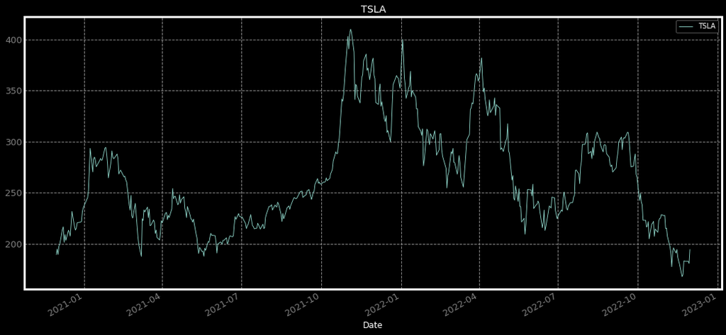

```python
stocks = ["TSLA"] #It can be a list
start = datetime(2020,11,30)
end = datetime(2022,11,30)
data = pdr.DataReader(stocks, 'yahoo',start,end)["Adj Close"]


plot(data , titulo='TSLA')
```

**Statistics:**

General statistics on TSLA's stock price in the last 2 years are shown, we can verify that in fact its volatility on a yearly basis is very high and its price range has been outstanding in the middle of a downtrend market.

```python
St=data.to_numpy()[-1]
S0=data.to_numpy()[-252]
display(dqr(data))
print("TSLA's last registered Price in:", data.index[-1].date(), "was:", St, " and 1 year ago it was anectodically:", S0)
```

|  | Name | Type | N/A value | Count values | Unique values | Min | Max | Mean | Std | Var | Median | Skewness | Kurtosis |
| --- | --- | --- | --- | --- | --- | --- | --- | --- | --- | --- | --- | --- | --- |
| TSLA | TSLA | float64 | 0 | 505 | 503 | 167.87 | 409.97 | 263.80 | 51.89 | 2693.08 | 250.97 | 0.65 | -0.36 |

```
TSLA's last registered Price in: 2022-11-30 was: [194.69999695]  and 1 year ago it was anectodically: [365.]
```

Over 2 years TSLA's metrics were the following:

```python
log_ret=np.log(data/data.shift(1)).dropna()
mean_ret = log_ret.mean() * 252
sig=log_ret.std()*np.sqrt(252)

stocks_summary = pd.DataFrame({"Mean Log_Returns (Yr)" : mean_ret, "Volatility (Yr)" : sig})
stocks_summary
```

| Symbols | Mean Log_Returns (Yr) | Volatility (Yr) |
| --- | --- | --- |
| TSLA | 0.01 | 0.60 |

##### Train & Test

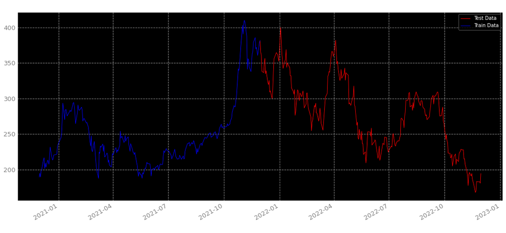

```python
stocks = ["TSLA"] #It can be a list
start_train = datetime(2020,11,30)
end_train = datetime(2021,11,30)
train = pdr.DataReader(stocks, 'yahoo',start_train,end_train)["Adj Close"]

start_train = datetime(2021,11,30)
end_train = datetime(2022,11,30)
test = pdr.DataReader(stocks, 'yahoo',start_train,end_train)["Adj Close"]


%matplotlib inline

fig = plt.figure(figsize = (16, 8))
test['TSLA'].plot(label="Test Data", linewidth=0.9, color='r')
train['TSLA'].plot(label="Train Data", linewidth=0.9, color='b')

plt.legend()
_ = plt.title(f"{stocks} stock price")
```

```python
train_np = [train][0].to_numpy()
test_np = [test][0].to_numpy()
S0train = train_np[0]
S0test = test_np[0]
train_mean = np.log(train/train.shift(1)).dropna().mean()*252
test_mean = np.log(test/test.shift(1)).dropna().mean()*252
train_std= (np.log(train/train.shift(1)).dropna()).std()*np.sqrt(252)
test_std = (np.log(test/test.shift(1)).dropna()).std()*np.sqrt(252)

stocks_summary = pd.DataFrame({"Mean Ret. Train (Yr)" : train_mean,
                                 "Mean Ret. Test (Yr)" : test_mean,
                                 "Std. Train (Yr)" : train_std,
                                 "Std. Test (Yr)" : test_std,
                                 "S0train": S0train,
                                 "S0test": S0test,
                                 "Sttest": test_np[-1]})
stocks_summary
```

| Symbols | Mean Ret. Train (Yr) | Mean Ret. Test (Yr) | Std. Train (Yr) | Std. Test (Yr) | S0train | S0test | Sttest |
| --- | --- | --- | --- | --- | --- | --- | --- |
| TSLA | 0.70 | -0.67 | 0.54 | 0.65 | 189.20 | 381.59 | 194.70 |

Call Option: Delta Neutral.

An options position can be hedged with one or various options with a delta opposite to that of the current position. The objective is to make the portfolio have an accumulated $\Delta$ of 0, a term which is widely known as: achieve *Delta Neutral*.  
Doing so will minimize the options portfolio price movements from underlying asset fluctuations.

When selling an option, Delta hedging allows the investor to anticipate to unfavorauble market conditions and to protect profits from past operations.  
A disadvantage for portfolio accumulated returns are the trading costs, so we need to have them in mind as well. It is important to note as well that the portfolio can suddenly get to be over-hedged by the market.

Opened positions should be constantly and appropiately rebalanced with the help of several techniques:

#### Greeks:

##### 1° order

$\Delta = \frac{\partial V}{\partial S}$

$\Theta = \frac{-\partial V}{\partial r}$

$\nu = \frac{\partial V}{\partial \sigma}$

$\rho = \frac{\partial V}{\partial r}$

$\epsilon = \frac{\partial V}{\partial q}$

##### 2° order

$\Gamma = \frac{\partial^2 V}{\partial S^2}$

Vanna = $\frac{\partial^2 V}{\partial S \partial \sigma}$

Charm = $\frac{\partial^2 V}{\partial \tau \partial S}$

Vomma = $\frac{\partial^2 V}{\partial \sigma^2}$

Veta = $\frac{\partial^2 V}{\partial \sigma \partial r}$

Vera = $\frac{\partial^2 V}{\partial \sigma \partial r}$

### Calculating $\Delta$

**Steps:**

1. Calculate Call fair price.

$V_t=S_t N\left(d_1\right)-K e^{-r(t-t)} N\left(d_2\right)$

1. Obtain the Partial Derivative with respect to $S_t$

$\frac{\delta V t}{\delta S_t}=\frac{\delta S_t}{\delta S_t} N\left(d_1\right) + \frac{\delta N\left(d_1\right)}{\delta d_1} \cdot S t \cdot \frac{\delta d_1}{\delta S_t} - Ke^{-r(t-t)} N'\left(d_2\right) $

1. Apply the chain rule property:

   $d[f(x) g(z)] = \frac{\delta f^{\prime}(x)}{\delta x} g(z)+\frac{g^{\prime}(z)}{d z} \cdot f(x) \cdot \frac{\delta z}{\delta x}$

$\frac{\delta V_t}{\delta S_t} = N\left(d_1\right) + \frac{d_1}{\delta S_t} \biggl [S_t N'(d1) - Ke^{-r(t-t)} N'\left(d_2\right) \biggr ]$

1. Apply property:

   $\frac{\delta d_1}{\delta S_t} = \frac{\delta d_2}{\delta S_t}$

$Ke^{-r(t-t)} N'\left(d_2\right) = S_t N'(d1)$

$\biggl [S_t N'(d1) - Ke^{-r(t-t)} N'\left(d_2\right) \biggr ] = 0$

$\frac{\delta V_t}{\delta S_t} = N\left(d_1\right) + \frac{d_1}{\delta S_t} [0]$

$\frac{\delta V_t}{\delta S_t} = N\left(d_1\right)$

- $X \sim \mathcal{N}(\mu,\,\sigma^{2})$
- *$N$ is the standard normal distribution function CDF.*

#### Result:

**$\delta = N(d_{1})$**

```python
np.array(list(range(300, 510, 10))).T
```

```
array([300, 310, 320, 330, 340, 350, 360, 370, 380, 390, 400, 410, 420,
       430, 440, 450, 460, 470, 480, 490, 500])
```

```python
#Mibian
S= S0
K_model=list(range(300, 510, 10)) #K = 152.0
#stocks_summary values.
r = -0.672878 # in pct, r = .01 (BS)
T = 365 # in days, T = 7/365  (BS)
sigma = 65.4335 # in pct, sigma =.30 (BS)

call, Delta, Gamma, Theta, Vega, Rho = ([] for x in range(6))
call_f = io.StringIO()
Delta_f = io.StringIO()
Gamma_f = io.StringIO()
Theta_f = io.StringIO()
Vega_f = io.StringIO()
Rho_f = io.StringIO()

for i in range(0,len(K_model)):
        print(([i for i in Mib_Call(S, K_model[i], T, r, sigma)][0]), file=call_f)
        print(([i for i in Mib_Call(S, K_model[i], T, r, sigma)][1]), file=Delta_f)
        print(([i for i in Mib_Call(S, K_model[i], T, r, sigma)][2]), file=Gamma_f)
        print(([i for i in Mib_Call(S, K_model[i], T, r, sigma)][3]), file=Theta_f)
        print(([i for i in Mib_Call(S, K_model[i], T, r, sigma)][4]), file=Vega_f)
        print(([i for i in Mib_Call(S, K_model[i], T, r, sigma)][5]), file=Rho_f)
        call = call_f.getvalue()
        call = pd.DataFrame((call.split())).astype(float)
        Delta = Delta_f.getvalue()
        Delta = pd.DataFrame((Delta.split())).astype(float)
        Gamma = Gamma_f.getvalue()
        Gamma = pd.DataFrame((Gamma.split())).astype(float)
        Theta = Theta_f.getvalue()
        Theta = pd.DataFrame((Theta.split())).astype(float)
        Vega = Vega_f.getvalue()
        Vega = pd.DataFrame((Vega.split())).astype(float)
        Rho = Rho_f.getvalue()
        Rho = pd.DataFrame((Rho.split())).astype(float)

df = pd.concat([call, Delta, Gamma, Theta, Vega, Rho], axis=1)
df.columns = ['Call_Price', 'Delta', 'Gamma', 'Theta', 'Vega', 'Rho']
df.index = K_model
# df=df.reset_index(drop=True)
df.index.name = 'K'
df
```

| K | Call_Price | Delta | Gamma | Theta | Vega | Rho |
| --- | --- | --- | --- | --- | --- | --- |
| 300 | 120.44 | 0.73 | 0.00 | -0.11 | 1.20 | 1.46 |
| 310 | 115.66 | 0.71 | 0.00 | -0.11 | 1.24 | 1.45 |
| 320 | 111.07 | 0.70 | 0.00 | -0.11 | 1.27 | 1.44 |
| 330 | 106.68 | 0.68 | 0.00 | -0.11 | 1.30 | 1.42 |
| 340 | 102.47 | 0.66 | 0.00 | -0.12 | 1.33 | 1.40 |
| 350 | 98.43 | 0.65 | 0.00 | -0.12 | 1.35 | 1.38 |
| 360 | 94.57 | 0.63 | 0.00 | -0.12 | 1.38 | 1.36 |
| 370 | 90.86 | 0.62 | 0.00 | -0.12 | 1.39 | 1.34 |
| 380 | 87.32 | 0.60 | 0.00 | -0.12 | 1.41 | 1.32 |
| 390 | 83.92 | 0.59 | 0.00 | -0.13 | 1.42 | 1.30 |
| 400 | 80.66 | 0.57 | 0.00 | -0.13 | 1.43 | 1.27 |
| 410 | 77.54 | 0.56 | 0.00 | -0.13 | 1.44 | 1.25 |
| 420 | 74.55 | 0.54 | 0.00 | -0.13 | 1.45 | 1.23 |
| 430 | 71.69 | 0.53 | 0.00 | -0.13 | 1.45 | 1.20 |
| 440 | 68.95 | 0.51 | 0.00 | -0.13 | 1.46 | 1.18 |
| 450 | 66.32 | 0.50 | 0.00 | -0.13 | 1.46 | 1.16 |
| 460 | 63.80 | 0.49 | 0.00 | -0.13 | 1.46 | 1.13 |
| 470 | 61.39 | 0.47 | 0.00 | -0.13 | 1.45 | 1.11 |
| 480 | 59.08 | 0.46 | 0.00 | -0.13 | 1.45 | 1.09 |
| 490 | 56.86 | 0.45 | 0.00 | -0.13 | 1.44 | 1.06 |
| 500 | 54.74 | 0.43 | 0.00 | -0.13 | 1.44 | 1.04 |

As we can see fair call prices that are ITM are way more expensive than those OTM and ITM.

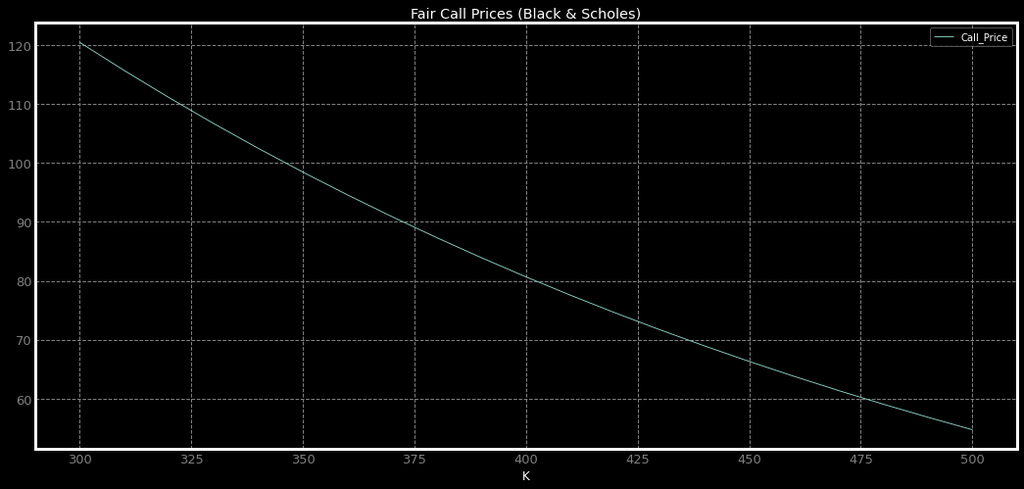

```python
plot(df[['Call_Price']] , titulo='Fair Call Prices (Black & Scholes)')
```

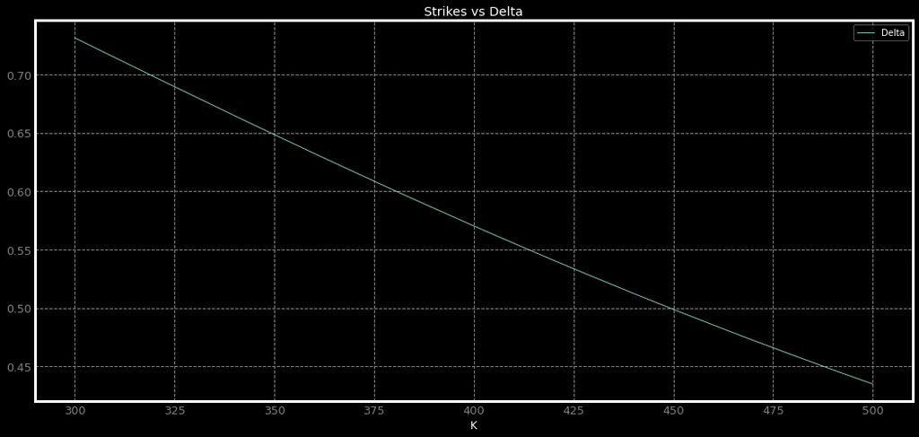

```python
plot(df[['Delta']] , titulo='Strikes vs Delta')
```

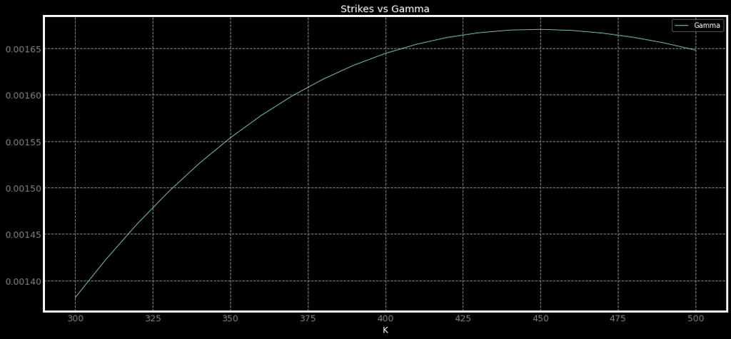

```python
plot(df[['Gamma']] , titulo='Strikes vs Gamma')
```

As we can see Theta is negative as it represents the option's value decay over the time, and it is higher on those that are OTM, because as time goes by they are less likely to be exercised.

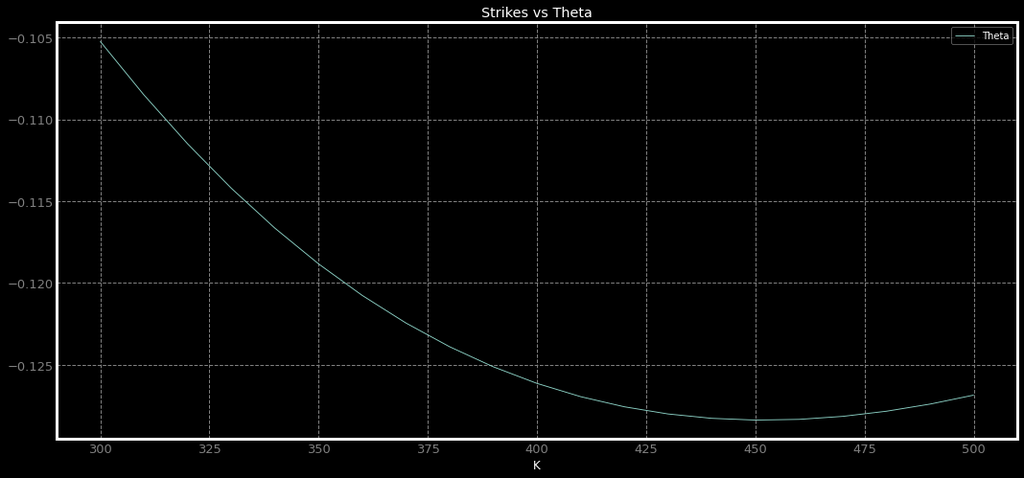

```python
plot(df[['Theta']] , titulo='Strikes vs Theta')
```

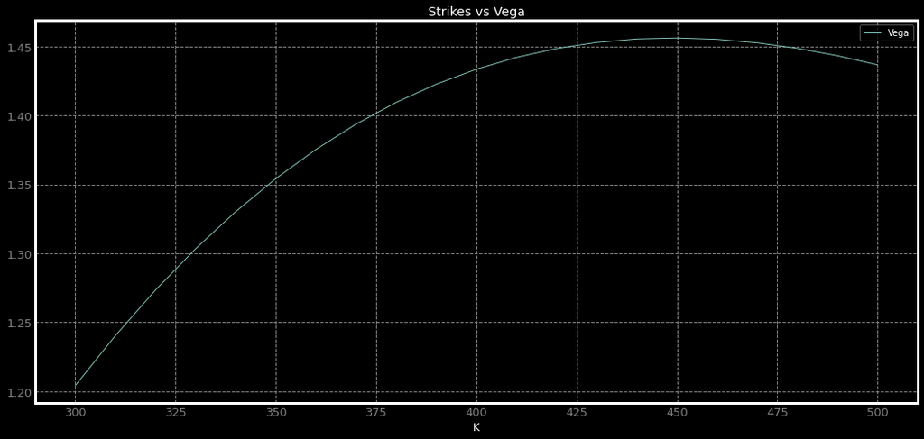

```python
plot(df[['Vega']] , titulo='Strikes vs Vega')
```

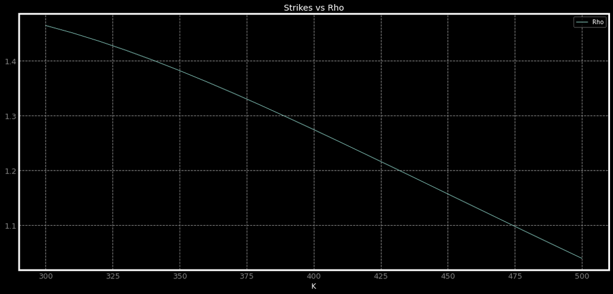

```python
plot(df[['Rho']] , titulo='Strikes vs Rho')
```

### Modeling Portfolio $\Pi$:

### $\Delta$ hedging

Steps:

Following the Black-Scholes model we will consider the stock price $S_t$ with the dynamics of the $V_t$ derivative using $S_t$ as the underlying. The Black-Scholes equation affirms that under conditions of no arbitrage, any derivative shows a behavior that satistfies the partial differential equation:

1. Derivatives partial differential equation.

$dV = \sigma S \frac{\partial V}{\partial S}dW + \bigg( \mu S \frac{\partial V}{\partial S} + \frac{1}{2}\sigma ^2 S^2 \frac{\partial^2 V}{\partial S^2} + \frac{\partial V}{\partial t} \bigg)dt$.

1. Price movements equation:

$ dS = \mu S dt + \sigma S dW $

1. Change expression and replace terms:

Assuming that the portfolio $\Pi$ has $x$ units of $S$ portffolio dynamics can then be expressed as:

$ d\Pi = dV - x dS$

Replacing $dV$ and x $dS$ in the value of the portfolio, the model can be expressed as:

$$d\Pi = \sigma S \frac{\partial V}{\partial S}dW + \bigg( \mu S \frac{\partial V}{\partial S} + \frac{1}{2}\sigma^2 S^2 \frac{\partial^2 V}{\partial S^2} + \frac{\partial V}{\partial t} \bigg)dt - x \bigg(\mu S dt + \sigma S dW \bigg)$$

1. Group $ d\Pi$ by common terms and reduce:

$$ d\Pi = \bigg(\mu S \frac{\partial V}{\partial S} + \frac{1}{2}\sigma^2 S^2 \frac{\partial^2 V}{\partial S^2} + \frac{\partial V}{\partial t} -x\mu S \bigg)dt + \bigg(\sigma S \frac{\partial V}{\partial S} - x \sigma S \bigg)dW $$

This can be reduced to:

$$ d\Pi = \bigg(\mu S \bigg(\frac{\partial V}{\partial S} - x \bigg)+ \frac{1}{2}\sigma^2 S^2 \frac{\partial^2 V}{\partial S^2} + \frac{\partial V}{\partial t} \bigg)dt + \sigma S \bigg(\frac{\partial V}{\partial S} - x \bigg)dW $$

If equal $x = \frac{\partial V}{\partial S}$ we can cancel the following terms:

$$ d\Pi = \bigg(\mu S [0] + \frac{1}{2}\sigma^2 S^2 \frac{\partial^2 V}{\partial S^2} + \frac{\partial V}{\partial t} \bigg)dt + \sigma S (0)dW $$

Finally, the dynamics of the portfolio are modelled by:

$d\Pi = \bigg(\frac{1}{2}\sigma^2 S^2 \frac{\partial^2 V}{\partial S^2} + \frac{\partial V}{\partial t} \bigg)dt$

Which can also be expressed with Greeks as:

$ d\Pi = \bigg(\frac{1}{2}\sigma^2 S^2 \Gamma + \Theta \bigg)dt$

### Short Call Hedging

When we Delta Hedge a Bare position we take the opposite position in every rebalance but when we Delta Hedge the short calls that we wrote, big positions are assumed in the underlying initially and they were gradually sold.

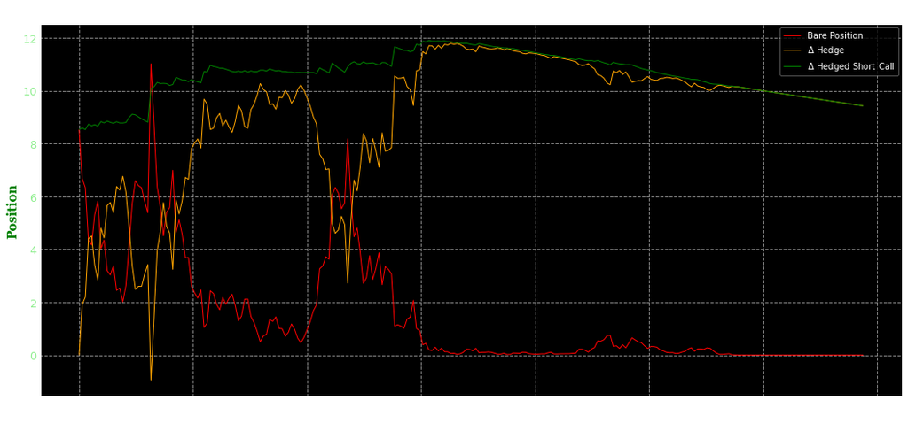

```python
option = mibian.BS([381.586669, 450, -0.672878*100, 1*252], volatility = 0.542047*100)
t_real, Vt_real, Strategies_real = delta_hedge(test_np.flatten(), option_to_hedge = option)

#Estética
plt.style.use('dark_background')
plt.rc('grid', linestyle="--", color='gray')
plt.rc('ytick', labelsize=13, color='lightgreen')
plt.rc('xtick', labelsize=11, color='white')


%matplotlib inline
fig = plt.figure(figsize=(16, 8))
plt.plot(t_real, Vt_real, label = 'Bare Position', color='r', linewidth=1)
plt.plot(t_real, -Strategies_real['DeltaHedge']['Value'], label = "$\Delta$ Hedge", color='orange', linewidth=1)
plt.plot(t_real, Vt_real-Strategies_real['DeltaHedge']['Value'], label = '$\Delta$ Hedged Short Call', color='green', linewidth=1)
_ = plt.legend()


#Estética
plt.title("Position on $\Delta$ Hedge and $\Delta$ Hedged Short Calls",size='17', weight='bold', family="Constantia")
plt.xlabel("Time",size='15', weight='roman', family="Georgia")
plt.ylabel("Position",size='15', weight='bold', family="Georgia", color='g')
plt.grid(True)
plt.legend(loc = "best")
```

The accumulated returns of out Delta Hedge were 11% by the end of the test.

```python
t_real, Vt_real, Strategies_real


DeltaHedge=pd.DataFrame(Vt_real-Strategies_real['DeltaHedge']['Value'])
DeltaHedgeretRacum=(DeltaHedge.pct_change()+1).cumprod()

dfh = pd.concat([DeltaHedge, DeltaHedgeretRacum], axis=1)
dfh.columns = ['DeltaHedge_Pos', 'Acum_Ret']

dfh.dropna()
```

|  | DeltaHedge_Pos | Acum_Ret |
| --- | --- | --- |
| 1 | 8.59 | 1.01 |
| 2 | 8.53 | 1.00 |
| 3 | 8.73 | 1.02 |
| 4 | 8.67 | 1.02 |
| 5 | 8.71 | 1.02 |
| ... | ... | ... |
| 247 | 9.49 | 1.11 |
| 248 | 9.48 | 1.11 |
| 249 | 9.46 | 1.11 |
| 250 | 9.44 | 1.11 |
| 251 | 9.42 | 1.11 |

251 rows × 2 columns

```python
warnings.filterwarnings("ignore", category=RuntimeWarning)
import pandas as pd
pd.options.display.float_format = '{:.2f}'.format
# Hedging Short Call with Long Stock:

N = 1000 # Short 10 call options
cost_of_shares=np.zeros
S0 = 381.586669; K = 420; T = 1.0; r = -0.672878*100; q = 0.0; sigma = 0.542047*100 #Data

N_steps = 52+1 #Rebalance times

#path = GBM_sim(S0, r- q, T, sigma ,N_steps)

St = data.iloc[-253:-1,:]['TSLA'].to_numpy();
ttm = 1.0 - np.arange(0,252,1)/251;
dt = T/N_steps

d = delta(St, K, ttm, r, q, sigma, 'Call')

# Initial Position
n_shares = [d[0]*N]
cost_of_shares = [n_shares[0]*S0]

commission = [cost_of_shares[0]*.005]

cumulative_cost = [n_shares[0]*S0]

acum_commission = [cumulative_cost[0]*.005]

#interest_cost = [cumulative_cost[0]*r*dt]



# Rebalancing
for i in range(1, len(d)):
    diff = d[i] - d[i-1]
    n_shares.append(diff*N)
    cost_of_shares.append(n_shares[i-1]*St[i-1])
    commission.append(cost_of_shares[i-1]*.005)
    cumulative_cost.append(cost_of_shares[i-1] + cumulative_cost[i-1] + commission[i-1])
    acum_commission.append(cumulative_cost[i-1]*.005)
    #interest_cost.append(cumulative_cost[i]*r*dt)



sim = pd.DataFrame({'Stock Price':St,'Shares Purchased':np.array(n_shares).round(0),
                    'Cost of Shares':np.array(cost_of_shares),
                    'Cumulative Cost':np.array(cumulative_cost),
                    'Commission (.50%)':np.array(commission),
                    'Acum. Commission':np.array(acum_commission)
                    })
sim.index.name = 'Days'
sim.tail()
```

| Days | Stock Price | Shares Purchased | Cost of Shares | Cumulative Cost | Commission (.50%) | Acum. Commission |
| --- | --- | --- | --- | --- | --- | --- |
| 247 | 169.91 | -1.00 | -26.70 | 1150474.99 | -0.03 | 5752.41 |
| 248 | 183.20 | -3.00 | -112.01 | 1150448.25 | -0.13 | 5752.37 |
| 249 | 182.86 | -13.00 | -501.05 | 1150336.11 | -0.56 | 5752.24 |
| 250 | 182.92 | -66.00 | -2324.70 | 1149834.50 | -2.51 | 5751.68 |
| 251 | 180.83 | -918.00 | -12080.56 | 1147507.29 | -11.62 | 5749.17 |

```python
#! jupyter nbconvert --to HTML --nbformat 3 Greek_Hedging_Proy_Respaldo2 --allow-errors (--no-input)  #NO CODE HTML OUTPUT
! jupyter nbconvert --to HTML --nbformat 3 Delta_Hedging_Final --allow-errors
```